# Lecture 1B. Data Validation

Zechariah Meunier

2026-01-08

Our goals as ecological and earth system data scientists are to extract meaning from big environmental data and to provide valuable insight to stakeholders. This can only be done through careful work with data at every stage in the data life cycle.

## Definitions

**Data validation** - process of ensuring that data are accurate (i.e., have correct values) and precise (i.e., have consistent values)

**Quality assurance (QA)** - systematic prevention of defects in a product or service so that they meet specified requirements

- proactive approach
- requires audit of the process or **input**

**Quality control (QC)** - identification and rectification of defects in a product or service so that they meet specified requirements

- reactive approach
- requires audit of the product or **output**

## Quality Assurance Considerations

The primary goal of QA is to scrub the errors from the input to the analytical pipeline.

1. Consider the format of the raw data:
- relational (i.e., tabular) vs. non-relational (e.g., document, graph) data
- row count and meaning
- column count and meaning
- data types (e.g., categorical or numerical)
- file type

Useful base R functions:

```r
head(CO2) #first 6 rows
```

```
##   Plant   Type  Treatment conc uptake
## 1   Qn1 Quebec nonchilled   95   16.0
## 2   Qn1 Quebec nonchilled  175   30.4
## 3   Qn1 Quebec nonchilled  250   34.8
## 4   Qn1 Quebec nonchilled  350   37.2
## 5   Qn1 Quebec nonchilled  500   35.3
## 6   Qn1 Quebec nonchilled  675   39.2
```

```r
tail(CO2,10) #last 10 rows
```

```
##    Plant        Type Treatment conc uptake
## 75   Mc2 Mississippi   chilled  500   12.5
## 76   Mc2 Mississippi   chilled  675   13.7
## 77   Mc2 Mississippi   chilled 1000   14.4
## 78   Mc3 Mississippi   chilled   95   10.6
## 79   Mc3 Mississippi   chilled  175   18.0
## 80   Mc3 Mississippi   chilled  250   17.9
## 81   Mc3 Mississippi   chilled  350   17.9
## 82   Mc3 Mississippi   chilled  500   17.9
## 83   Mc3 Mississippi   chilled  675   18.9
## 84   Mc3 Mississippi   chilled 1000   19.9
```

```r
nrow(CO2) #number of rows
```

```
## [1] 84
```

```r
ncol(CO2) #number of columns
```

```
## [1] 5
```

2. Consider the values of each variable:
- minimum and maximum, especially outliers beyond physical limits (e.g., water temperature above 20$^\circ$C on the Oregon coast)
- characters instead of numerics
- appropriate units and scale
- combinations of values

Useful R functions:

```r
summary(CO2)
```

```
##      Plant             Type         Treatment       conc          uptake
##  Qn1    : 7   Quebec     :42   nonchilled:42   Min.   :  95   Min.   : 7.70
##  Qn2    : 7   Mississippi:42   chilled   :42   1st Qu.: 175   1st Qu.:17.90
##  Qn3    : 7                                    Median : 350   Median :28.30
##  Qc1    : 7                                    Mean   : 435   Mean   :27.21
##  Qc3    : 7                                    3rd Qu.: 675   3rd Qu.:37.12
##  Qc2    : 7                                    Max.   :1000   Max.   :45.50
##  (Other):42
```

```r
min(CO2$conc)
```

```
## [1] 95
```

```r
max(CO2$conc)
```

```
## [1] 1000
```

```r
class(CO2$Type)
```

```
## [1] "factor"
```

```r
unique(CO2$Type)
```

```
## [1] Quebec      Mississippi
## Levels: Quebec Mississippi
```

```r
table(CO2$Type, CO2$Treatment)
```

```
##
##               nonchilled chilled
##   Quebec              21      21
##   Mississippi         21      21
```

```r
skimr::skim(CO2)
```

Data summary

| Name | CO2 |
| --- | --- |
| Number of rows | 84 |
| Number of columns | 5 |
| _______________________ |  |
| Column type frequency: |  |
| factor | 3 |
| numeric | 2 |
| ________________________ |  |
| Group variables | None |

**Variable type: factor**

| skim_variable | n_missing | complete_rate | ordered | n_unique | top_counts |
| --- | --- | --- | --- | --- | --- |
| Plant | 0 | 1 | TRUE | 12 | Qn1: 7, Qn2: 7, Qn3: 7, Qc1: 7 |
| Type | 0 | 1 | FALSE | 2 | Que: 42, Mis: 42 |
| Treatment | 0 | 1 | FALSE | 2 | non: 42, chi: 42 |

**Variable type: numeric**

| skim_variable | n_missing | complete_rate | mean | sd | p0 | p25 | p50 | p75 | p100 | hist |
| --- | --- | --- | --- | --- | --- | --- | --- | --- | --- | --- |
| conc | 0 | 1 | 435.00 | 295.92 | 95.0 | 175.0 | 350.0 | 675.00 | 1000.0 | ▇▂▂▂▂ |
| uptake | 0 | 1 | 27.21 | 10.81 | 7.7 | 17.9 | 28.3 | 37.12 | 45.5 | ▇▇▅▇▇ |

## Quality Control Considerations

The primary goal of QC is to scrub the errors from the output from the analytical pipeline.

1. Consider future data users:
- Do the metadata explicitly explain basic information about the data that can make tracking and working with the data easier?
- Will other scientists be able to interpret my summary figures and tables?
- Will other scientists or future me be able to read and understand my code?
2. Consider the stakeholders:
- Will non-scientist subject matter experts be able to interpret my summary figures and tables?
- Do my products contain proprietary information that must be redacted?

## NOAA Data Example

We’ll work with a simple dataset from the National Oceanic and Atmospheric Administration (NOAA). These data are the bimonthly values for the Multivariate El Niño Southern Oscillation Index (https://psl.noaa.gov/enso/mei/) or MEI for short. Our end goal is to create a time series showing the El Niño and La Niña events over the past 47 years.

First, let’s load the input data. There are four versions of the data:

- raw data updated on March 10, 2025
- cleaned data updated on March 10, 2025
- raw data updated on January 8, 2026
- cleaned data updated on January 8, 2026

```r
MEI_raw_1 <- read.delim("MEI_raw_20250310.txt")
MEI1 <- read.table("MEI_cleaned_20250310.txt", header = TRUE)
MEI_raw_2 <- read.delim("MEI_raw_20260108.txt")
MEI2 <- read.table("MEI_cleaned_20260108.txt", header = TRUE)
```

Now take a look at the MEI_raw vs. MEI_cleaned files for the older version. In this case, it was easiest to work with the data in a text editor, but larger files might need to be manipulated in R.

```r
View(MEI_raw_1)
View(MEI1)
```

To view the top few rows of the data frame, use the `head` function. Similarly, use the `tail` function to view the bottom few rows.

```r
head(MEI1)
```

```
##   YEAR    DJ    JF    FM    MA    AM    MJ    JJ    JA    AS    SO    ON    ND
## 1 1979  0.47  0.29 -0.05  0.21  0.27 -0.11 -0.11  0.47  0.38  0.23  0.53  0.63
## 2 1980  0.33  0.20  0.39  0.51  0.45  0.55  0.47  0.03  0.12  0.02 -0.07 -0.12
## 3 1981 -0.36 -0.23  0.33  0.43 -0.24 -0.70 -0.61 -0.34 -0.07 -0.16 -0.27 -0.19
## 4 1982 -0.43 -0.49 -0.27 -0.36 -0.12  0.62  1.65  1.91  1.69  1.78  2.14  2.37
## 5 1983  2.48  2.68  2.61  2.76  2.86  1.98  0.63 -0.17 -0.49 -0.53 -0.47 -0.50
## 6 1984 -0.54 -0.56 -0.16  0.07 -0.45 -0.66 -0.34 -0.20 -0.14 -0.19 -0.58 -0.28
```

```r
tail(MEI1)
```

```
##    YEAR    DJ    JF      FM      MA      AM      MJ      JJ      JA      AS
## 42 2020  0.25  0.26    0.13   -0.15   -0.23   -0.68   -0.94   -0.96   -1.15
## 43 2021 -1.20 -0.96   -0.79   -0.95   -1.07   -1.05   -1.44   -1.29   -1.38
## 44 2022 -1.01 -0.98   -1.31   -1.61   -1.63   -1.90   -2.17   -1.75   -1.73
## 45 2023 -1.11 -0.91   -0.76   -0.37   -0.06    0.43    0.50    0.51    0.68
## 46 2024  0.70  0.68    0.78    0.34    0.12   -0.23   -0.72   -0.73   -0.65
## 47 2025 -1.00 -0.83 -999.00 -999.00 -999.00 -999.00 -999.00 -999.00 -999.00
##         SO      ON      ND
## 42   -1.17   -1.13   -1.14
## 43   -1.46   -1.39   -1.20
## 44   -1.73   -1.53   -1.28
## 45    0.48    0.91    1.13
## 46   -0.52   -0.68   -0.91
## 47 -999.00 -999.00 -999.00
```

As you can see, there’s an issue with the last row having -999.000 as a placeholder instead of `NA`. There are several ways to convert these values, some of which are more work than others.

We could manually replace the values in a vector using `replace` and fix it in 10 lines of code.

```r
MEI1$FM <- replace(MEI1$FM, MEI1$FM == -999, NA)
MEI1$MA <- replace(MEI1$MA, MEI1$MA == -999, NA)
MEI1$AM <- replace(MEI1$AM, MEI1$AM == -999, NA)
MEI1$MJ <- replace(MEI1$MJ, MEI1$MJ == -999, NA)
MEI1$JJ <- replace(MEI1$JJ, MEI1$JJ == -999, NA)
MEI1$JA <- replace(MEI1$JA, MEI1$JA == -999, NA)
MEI1$AS <- replace(MEI1$AS, MEI1$AS == -999, NA)
MEI1$SO <- replace(MEI1$SO, MEI1$SO == -999, NA)
MEI1$ON <- replace(MEI1$ON, MEI1$ON == -999, NA)
MEI1$ND <- replace(MEI1$ND, MEI1$ND == -999, NA)
tail(MEI1)
```

```
##    YEAR    DJ    JF    FM    MA    AM    MJ    JJ    JA    AS    SO    ON    ND
## 42 2020  0.25  0.26  0.13 -0.15 -0.23 -0.68 -0.94 -0.96 -1.15 -1.17 -1.13 -1.14
## 43 2021 -1.20 -0.96 -0.79 -0.95 -1.07 -1.05 -1.44 -1.29 -1.38 -1.46 -1.39 -1.20
## 44 2022 -1.01 -0.98 -1.31 -1.61 -1.63 -1.90 -2.17 -1.75 -1.73 -1.73 -1.53 -1.28
## 45 2023 -1.11 -0.91 -0.76 -0.37 -0.06  0.43  0.50  0.51  0.68  0.48  0.91  1.13
## 46 2024  0.70  0.68  0.78  0.34  0.12 -0.23 -0.72 -0.73 -0.65 -0.52 -0.68 -0.91
## 47 2025 -1.00 -0.83    NA    NA    NA    NA    NA    NA    NA    NA    NA    NA
```

We could use a for-loop and fix it in 4 lines of code.

```r
MEI1 <- read.table("MEI_cleaned_20250310.txt", header = TRUE)

for (i in 1:ncol(MEI1)) {
  col <- colnames(MEI1)[i]
  MEI1[[col]] <- replace(MEI1[[col]], MEI1[[col]] == -999, NA)
}

tail(MEI1)
```

```
##    YEAR    DJ    JF    FM    MA    AM    MJ    JJ    JA    AS    SO    ON    ND
## 42 2020  0.25  0.26  0.13 -0.15 -0.23 -0.68 -0.94 -0.96 -1.15 -1.17 -1.13 -1.14
## 43 2021 -1.20 -0.96 -0.79 -0.95 -1.07 -1.05 -1.44 -1.29 -1.38 -1.46 -1.39 -1.20
## 44 2022 -1.01 -0.98 -1.31 -1.61 -1.63 -1.90 -2.17 -1.75 -1.73 -1.73 -1.53 -1.28
## 45 2023 -1.11 -0.91 -0.76 -0.37 -0.06  0.43  0.50  0.51  0.68  0.48  0.91  1.13
## 46 2024  0.70  0.68  0.78  0.34  0.12 -0.23 -0.72 -0.73 -0.65 -0.52 -0.68 -0.91
## 47 2025 -1.00 -0.83    NA    NA    NA    NA    NA    NA    NA    NA    NA    NA
```

We could use the `lapply` function and fix it in 1 line of code.

```r
MEI1 <- read.table("MEI_cleaned_20250310.txt", header = TRUE)

MEI1[] <- lapply(MEI1, function(x) replace(x, x == -999, NA))

tail(MEI1)
```

```
##    YEAR    DJ    JF    FM    MA    AM    MJ    JJ    JA    AS    SO    ON    ND
## 42 2020  0.25  0.26  0.13 -0.15 -0.23 -0.68 -0.94 -0.96 -1.15 -1.17 -1.13 -1.14
## 43 2021 -1.20 -0.96 -0.79 -0.95 -1.07 -1.05 -1.44 -1.29 -1.38 -1.46 -1.39 -1.20
## 44 2022 -1.01 -0.98 -1.31 -1.61 -1.63 -1.90 -2.17 -1.75 -1.73 -1.73 -1.53 -1.28
## 45 2023 -1.11 -0.91 -0.76 -0.37 -0.06  0.43  0.50  0.51  0.68  0.48  0.91  1.13
## 46 2024  0.70  0.68  0.78  0.34  0.12 -0.23 -0.72 -0.73 -0.65 -0.52 -0.68 -0.91
## 47 2025 -1.00 -0.83    NA    NA    NA    NA    NA    NA    NA    NA    NA    NA
```

How do the two versions of the cleaned data compare to each other? Are there any major changes? To answer these questions, we can do a quick subtraction of one dataset from another, ignoring the first column of each.

```r
MEIdiff <- MEI2[,-1] - MEI1[,-1]
max(MEIdiff, na.rm = T)
```

```
## [1] 0.01
```

```r
min(MEIdiff, na.rm = T)
```

```
## [1] -0.03
```

Since there aren’t any major discrepancies, let’s use the most recent version of the dataset moving forward.

```r
MEI <- MEI2
```

To check how R stores the data in the table and columns, use the `class` function.

```r
class(MEI)
```

```
## [1] "data.frame"
```

```r
class(MEI$YEAR)
```

```
## [1] "integer"
```

```r
class(MEI$DJ)
```

```
## [1] "numeric"
```

Now let’s get a sense of the spread of the data using the function `summary`.

```r
summary(MEI)
```

```
##       YEAR            DJ                 JF                 FM
##  Min.   :1979   Min.   :-1.77000   Min.   :-1.59000   Min.   :-1.75000
##  1st Qu.:1990   1st Qu.:-0.84500   1st Qu.:-0.75500   1st Qu.:-0.67000
##  Median :2002   Median :-0.06000   Median :-0.23000   Median :-0.19000
##  Mean   :2002   Mean   :-0.06085   Mean   :-0.04128   Mean   :-0.04043
##  3rd Qu.:2014   3rd Qu.: 0.54500   3rd Qu.: 0.47500   3rd Qu.: 0.46000
##  Max.   :2025   Max.   : 2.47000   Max.   : 2.66000   Max.   : 2.60000
##        MA                 AM                 MJ                 JJ
##  Min.   :-1.69000   Min.   :-1.63000   Min.   :-1.90000   Min.   :-2.4200
##  1st Qu.:-0.65500   1st Qu.:-0.64500   1st Qu.:-0.81000   1st Qu.:-0.7700
##  Median :-0.17000   Median :-0.23000   Median :-0.17000   Median :-0.0500
##  Mean   :-0.05532   Mean   :-0.05787   Mean   :-0.09319   Mean   :-0.1226
##  3rd Qu.: 0.26000   3rd Qu.: 0.21500   3rd Qu.: 0.35000   3rd Qu.: 0.4650
##  Max.   : 2.75000   Max.   : 2.85000   Max.   : 2.34000   Max.   : 2.2700
##        JA                 AS                SO                ON
##  Min.   :-2.38000   Min.   :-2.2600   Min.   :-2.1600   Min.   :-2.01000
##  1st Qu.:-0.72500   1st Qu.:-0.8350   1st Qu.:-0.7000   1st Qu.:-0.81500
##  Median :-0.02000   Median :-0.1000   Median :-0.1600   Median :-0.16000
##  Mean   :-0.09106   Mean   :-0.1023   Mean   :-0.1074   Mean   :-0.08234
##  3rd Qu.: 0.49000   3rd Qu.: 0.5550   3rd Qu.: 0.5400   3rd Qu.: 0.63000
##  Max.   : 2.27000   Max.   : 2.2400   Max.   : 2.1500   Max.   : 2.14000
##        ND
##  Min.   :-1.85000
##  1st Qu.:-0.84500
##  Median :-0.12000
##  Mean   :-0.06766
##  3rd Qu.: 0.63500
##  Max.   : 2.36000
```

Another nice way of summarizing data is to use the `boxplot` function.

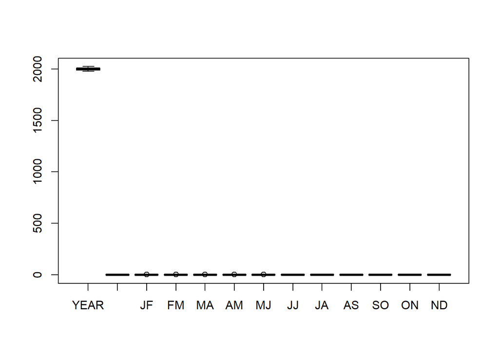

```r
boxplot(MEI)
```

As you can see, the year column is distorting the y-axis, so let’s remove it by indexing into the columns and removing the first column.

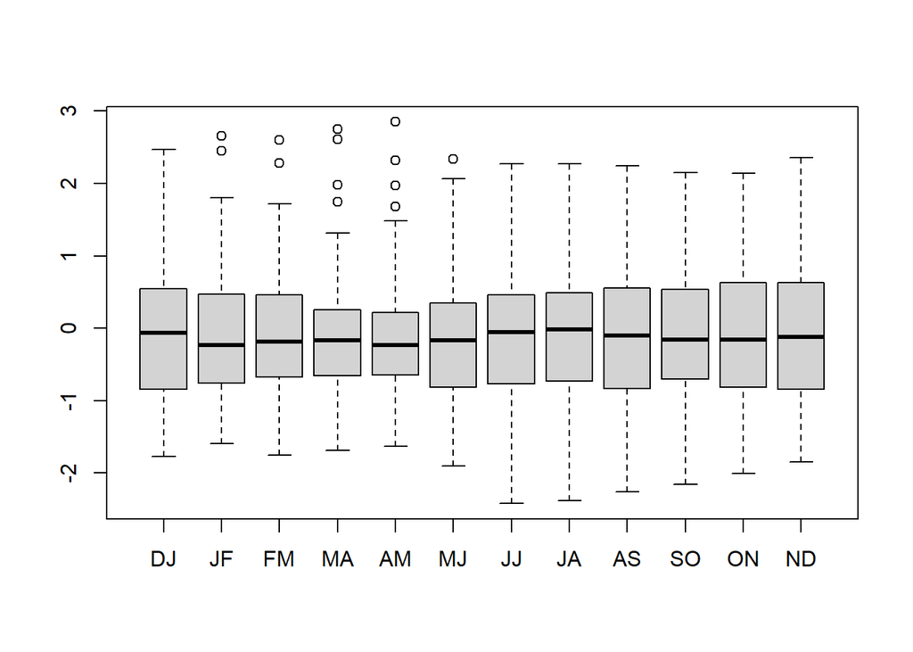

```r
boxplot(MEI[,-1])
```

Add x-axis and y-axis labels to make it more readable.

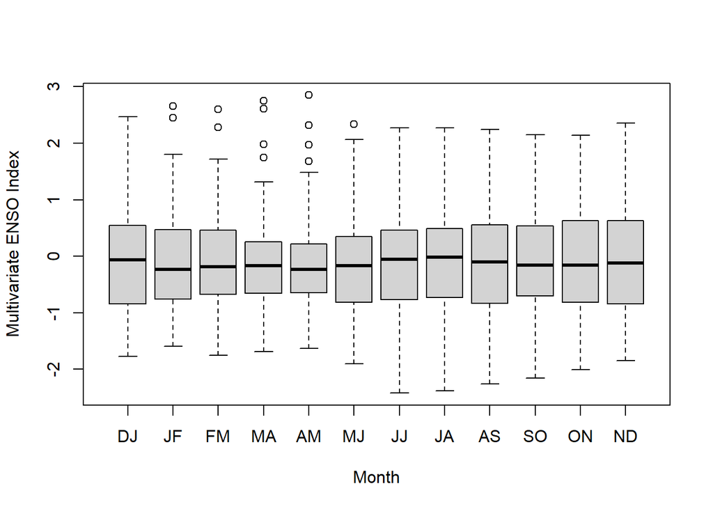

```r
boxplot(MEI[,-1], ylab = "Multivariate ENSO Index", xlab = "Month")
```

Of course, these data actually represent a time series, which is best plotted using a line graph. We need to wrangle our dataset to plot a time series, which we’ll do using functions from the R packages `tidyr`, `dplyr`, and `ggplot2`.

The dataset is currently in “wide” format, meaning there are redundant variable types across the columns. We need to convert it to “long” format, so that the same variables are stacked in a single column. We’ll use the function `pivot_longer` to achieve this. The important arguments are:

- `cols` for the columns to pivot into longer format
- `names_to` to specify the new column to create from the information stored in `cols`
- `values_to` to specify the new column to create from the data stored in the cell values.

```r
MEI_long <- MEI %>%
  pivot_longer(cols = DJ:ND, names_to = "Month", values_to = "MEI")

head(MEI_long)
```

```
## # A tibble: 6 × 3
##    YEAR Month   MEI
##   <int> <chr> <dbl>
## 1  1979 DJ     0.46
## 2  1979 JF     0.29
## 3  1979 FM    -0.05
## 4  1979 MA     0.22
## 5  1979 AM     0.27
## 6  1979 MJ    -0.11
```

Now we want to create a new column that combines the information stored in `YEAR` and `Month`. However, `Month` currently stores a 2-letter code that R doesn’t understand, so first we need to create another column with numerical data. We’ll make these new columns with the function `mutate`.

```r
MEI_long <- MEI_long %>%
  mutate(MonthNum = case_match(Month,
                               "DJ" ~ "01",
                               "JF" ~ "02",
                               "FM" ~ "03",
                               "MA" ~ "04",
                               "AM" ~ "05",
                               "MJ" ~ "06",
                               "JJ" ~ "07",
                               "JA" ~ "08",
                               "AS" ~ "09",
                               "SO" ~ "10",
                               "ON" ~ "11",
                               "ND" ~ "12"),
         Date = paste0(MonthNum, "/" , 1, "/", YEAR))

MEI_long$Date <- as.Date(MEI_long$Date, "%m/%d/%Y")

head(MEI_long)
```

```
## # A tibble: 6 × 5
##    YEAR Month   MEI MonthNum Date
##   <int> <chr> <dbl> <chr>    <date>
## 1  1979 DJ     0.46 01       1979-01-01
## 2  1979 JF     0.29 02       1979-02-01
## 3  1979 FM    -0.05 03       1979-03-01
## 4  1979 MA     0.22 04       1979-04-01
## 5  1979 AM     0.27 05       1979-05-01
## 6  1979 MJ    -0.11 06       1979-06-01
```

Let’s make a quick line graph showing the Multivariate ENSO Index over time!

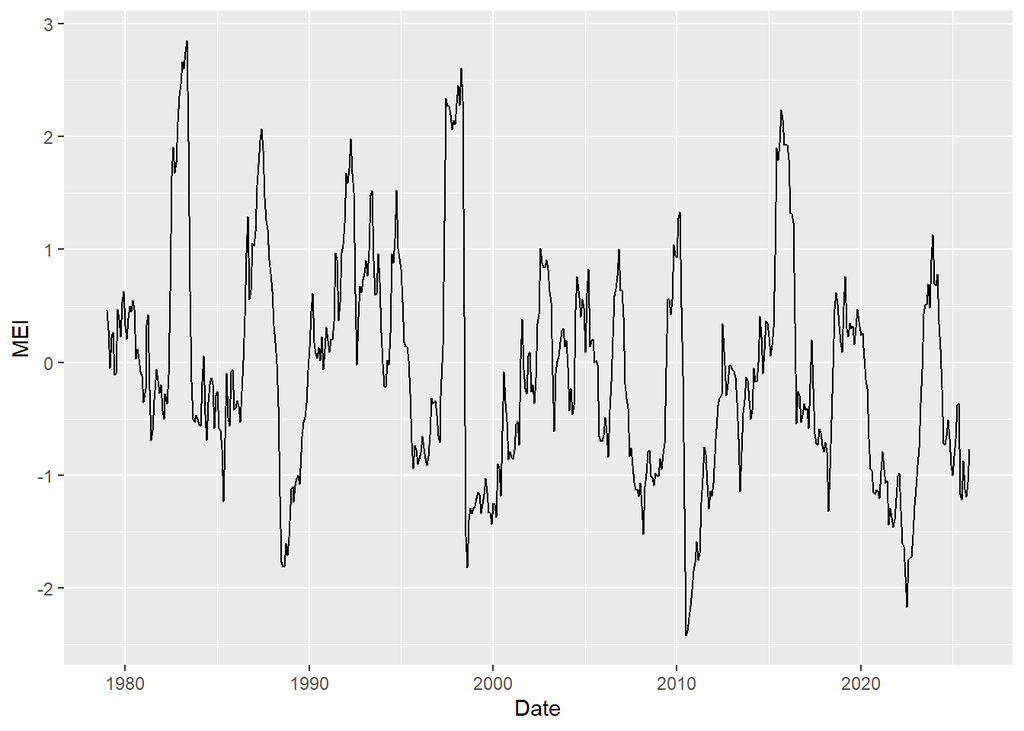

```r
MEIseries <- ggplot(data = MEI_long, aes(x = Date, y = MEI)) +
  geom_line()

MEIseries
```

We have two new products: a dataframe called `MEI_long` and a time series plot called `MEIseries`. Now let’s follow the principles of quality control to improve these data products!

First, let’s make our dataset more meaningful by categorizing the bimonthly MEI as El Niño (MEI $\ge 0.5$), neutral ($-0.5 <$ MEI $< 0.5$), or La Niña (MEI $\le -0.5$). We’ll make a new column to store the ENSO phase using `mutate` and nested `if_else` statements. Let’s make sure our logic was applied correctly using the `table` function.

```r
MEI_long <- MEI_long %>%
  mutate(ENSOphase = if_else(MEI < -0.49, "La Nina",
                             if_else(MEI > 0.49, "El Nino",
                                     "Neutral")))

table(MEI_long$ENSOphase, MEI_long$MEI)
```

```
##
##           -2.42 -2.38 -2.26 -2.17 -2.16 -2.01 -1.9 -1.85 -1.82 -1.81 -1.77
##   El Nino     0     0     0     0     0     0    0     0     0     0     0
##   La Nina     1     1     1     1     1     1    1     1     1     2     2
##   Neutral     0     0     0     0     0     0    0     0     0     0     0
##
##           -1.75 -1.73 -1.72 -1.71 -1.69 -1.63 -1.6 -1.59 -1.55 -1.54 -1.53
##   El Nino     0     0     0     0     0     0    0     0     0     0     0
##   La Nina     2     1     1     1     1     1    2     1     1     1     1
##   Neutral     0     0     0     0     0     0    0     0     0     0     0
##
##           -1.52 -1.46 -1.44 -1.43 -1.4 -1.39 -1.37 -1.34 -1.33 -1.32 -1.31 -1.3
##   El Nino     0     0     0     0    0     0     0     0     0     0     0    0
##   La Nina     1     1     1     1    1     1     2     2     2     1     1    1
##   Neutral     0     0     0     0    0     0     0     0     0     0     0    0
##
##           -1.29 -1.28 -1.27 -1.26 -1.25 -1.24 -1.23 -1.22 -1.2 -1.19 -1.18
##   El Nino     0     0     0     0     0     0     0     0    0     0     0
##   La Nina     4     1     2     2     1     2     1     1    3     2     3
##   Neutral     0     0     0     0     0     0     0     0    0     0     0
##
##           -1.17 -1.15 -1.14 -1.13 -1.12 -1.11 -1.1 -1.09 -1.08 -1.07 -1.06
##   El Nino     0     0     0     0     0     0    0     0     0     0     0
##   La Nina     4     3     3     2     3     1    2     2     2     3     2
##   Neutral     0     0     0     0     0     0    0     0     0     0     0
##
##           -1.05 -1.03 -1.02 -1.01 -1 -0.99 -0.98 -0.96 -0.95 -0.94 -0.91 -0.9
##   El Nino     0     0     0     0  0     0     0     0     0     0     0    0
##   La Nina     1     3     1     4  2     1     2     2     2     4     4    2
##   Neutral     0     0     0     0  0     0     0     0     0     0     0    0
##
##           -0.87 -0.86 -0.85 -0.84 -0.83 -0.81 -0.8 -0.79 -0.78 -0.77 -0.76
##   El Nino     0     0     0     0     0     0    0     0     0     0     0
##   La Nina     1     2     3     2     3     2    2     5     2     3     3
##   Neutral     0     0     0     0     0     0    0     0     0     0     0
##
##           -0.75 -0.74 -0.73 -0.72 -0.71 -0.7 -0.69 -0.68 -0.67 -0.66 -0.65
##   El Nino     0     0     0     0     0    0     0     0     0     0     0
##   La Nina     1     2     3     3     3    2     2     5     1     3     2
##   Neutral     0     0     0     0     0    0     0     0     0     0     0
```

[output cut: 65 more lines]

```
##
##           1.8 1.88 1.9 1.91 1.93 1.95 1.96 1.97 1.98 2.06 2.07 2.11 2.13 2.14
##   El Nino   1    1   1    1    3    1    1    1    1    1    1    1    1    1
##   La Nina   0    0   0    0    0    0    0    0    0    0    0    0    0    0
##   Neutral   0    0   0    0    0    0    0    0    0    0    0    0    0    0
##
##           2.15 2.2 2.24 2.27 2.28 2.29 2.32 2.34 2.36 2.45 2.47 2.6 2.61 2.66
##   El Nino    1   1    1    2    1    1    1    1    1    1    1   1    1    1
##   La Nina    0   0    0    0    0    0    0    0    0    0    0   0    0    0
##   Neutral    0   0    0    0    0    0    0    0    0    0    0   0    0    0
##
##           2.75 2.85
##   El Nino    1    1
##   La Nina    0    0
##   Neutral    0    0
```

While our categories are correct, notice how the ENSO phases appear in alphabetical order, even though the ENSO phase variable actually shows ordinal data. Let’s save this as a factor and set the levels of the factor in the correct order.

```r
MEI_long$ENSOphase <- factor(MEI_long$ENSOphase,
                             levels = c("La Nina","Neutral","El Nino"))

head(MEI_long)
```

```
## # A tibble: 6 × 6
##    YEAR Month   MEI MonthNum Date       ENSOphase
##   <int> <chr> <dbl> <chr>    <date>     <fct>
## 1  1979 DJ     0.46 01       1979-01-01 Neutral
## 2  1979 JF     0.29 02       1979-02-01 Neutral
## 3  1979 FM    -0.05 03       1979-03-01 Neutral
## 4  1979 MA     0.22 04       1979-04-01 Neutral
## 5  1979 AM     0.27 05       1979-05-01 Neutral
## 6  1979 MJ    -0.11 06       1979-06-01 Neutral
```

Great! Now let’s work on improving our plot `MEIseries` using some default themes.

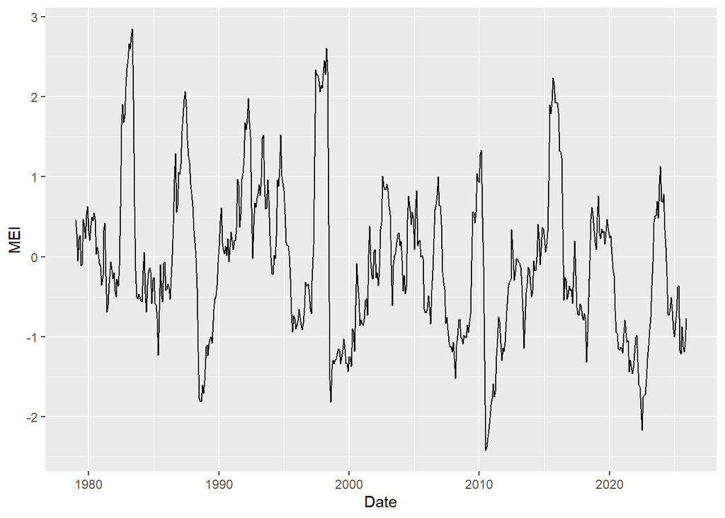

```r
MEIseries
```

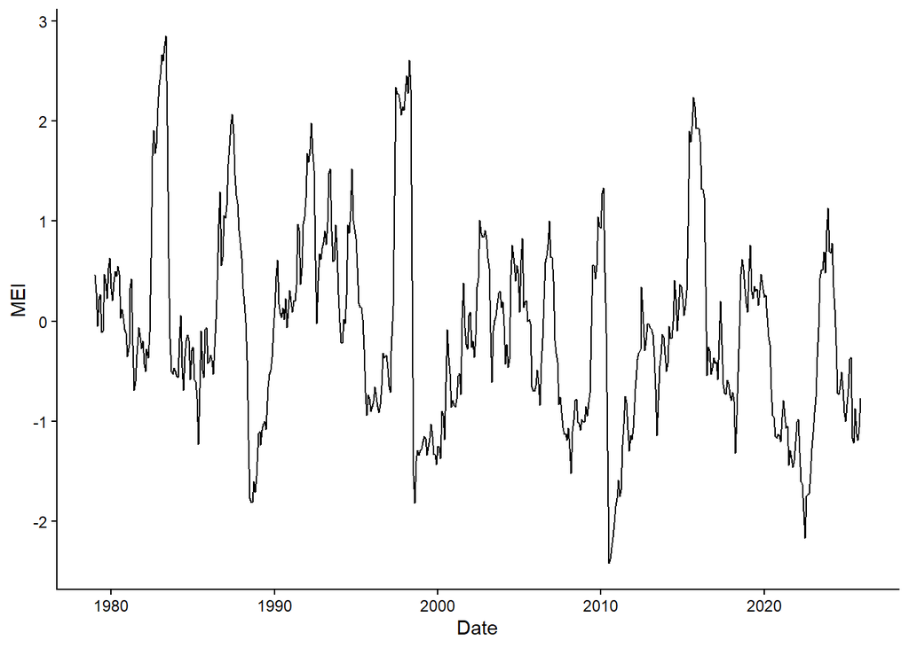

```r
MEIseries + theme_classic()
```

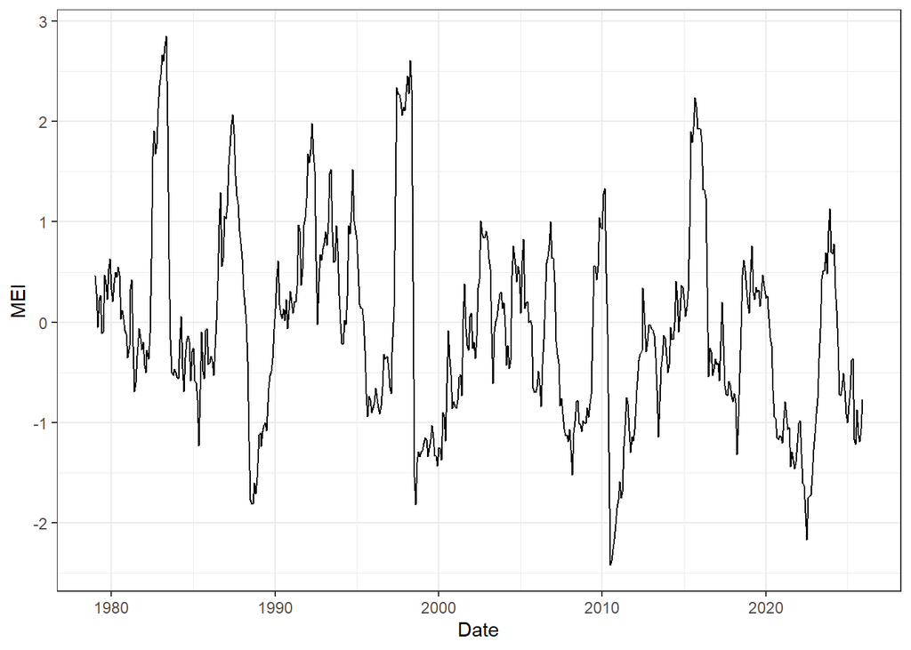

```r
MEIseries + theme_bw()
```

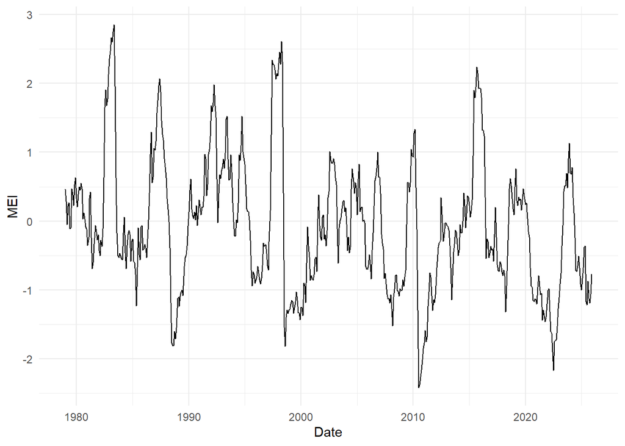

```r
MEIseries + theme_minimal()
```

Because journals do not typically want the horizontal or vertical grid lines on plots, `theme_classic` is the best choice here. But there are important thresholds in these data, so we’ll add three horizontal lines using `geom_hline`.

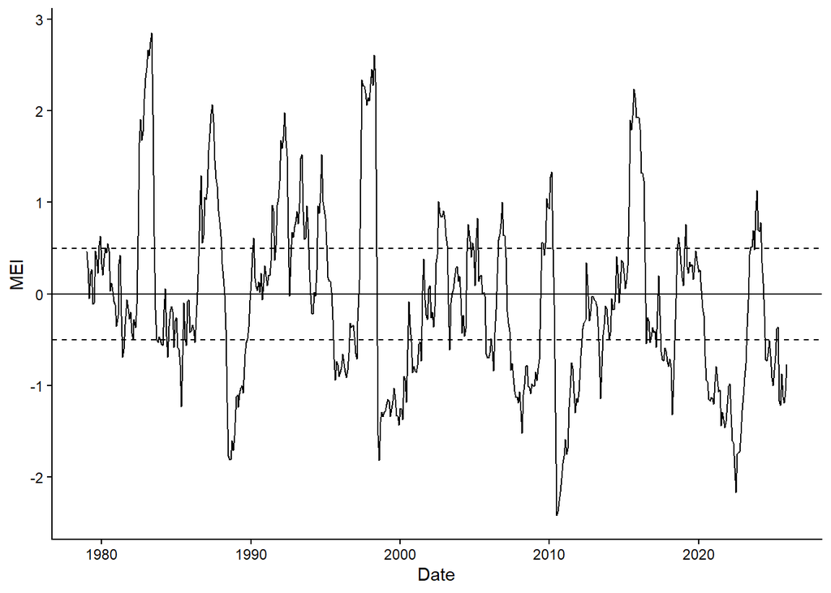

```r
MEIseries + theme_classic() +
  geom_hline(yintercept = 0, linetype = "solid") +
  geom_hline(yintercept = 0.5, linetype = "dashed") +
  geom_hline(yintercept = -0.5, linetype = "dashed")
```

Now we can see when the time series was in the three ENSO phases, but let’s add some colored columns to make it more obvious! We’ll also remove the missing data from `MEI_long` using `filter`.

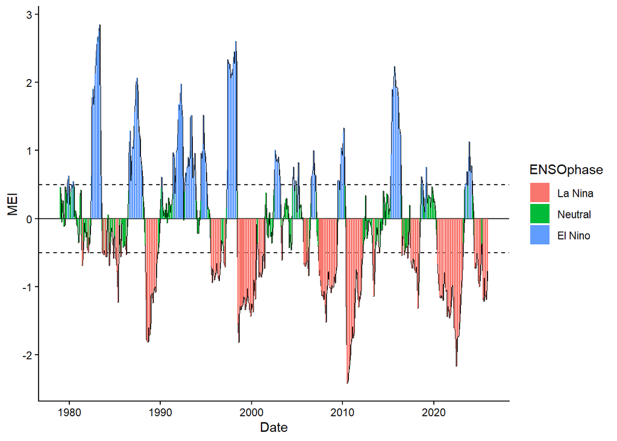

```r
ggplot(data = filter(MEI_long, !is.na(MEI)), aes(x = Date, y = MEI)) +
  geom_line() + theme_classic() +
  geom_hline(yintercept = 0, linetype = "solid") +
  geom_hline(yintercept = 0.5, linetype = "dashed") +
  geom_hline(yintercept = -0.5, linetype = "dashed") +
  geom_col(aes(x = Date, y = MEI, fill = ENSOphase))
```

The default colors don’t match our intuition of El Niño being warm and La Niña being cool, so let’s change these using `scale_fill_manual`. We’ll also use the character code for ñ (`\u00F1`). In addition, let’s make the black line bigger and draw it on top of the columns.

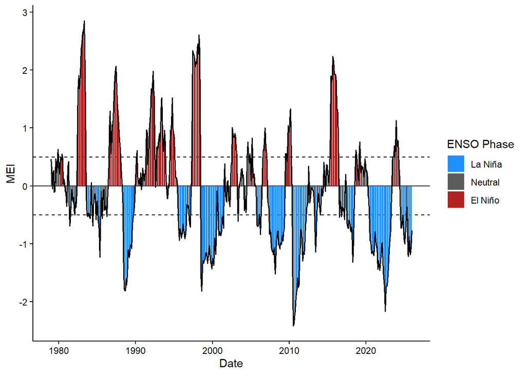

```r
ggplot(data = filter(MEI_long, !is.na(MEI)), aes(x = Date, y = MEI)) +
  theme_classic() +
  geom_hline(yintercept = 0, linetype = "solid") +
  geom_hline(yintercept = 0.5, linetype = "dashed") +
  geom_hline(yintercept = -0.5, linetype = "dashed") +
  geom_col(aes(x = Date, y = MEI, fill = ENSOphase)) +
  geom_line(linewidth = 0.7) +
  scale_fill_manual(name = "ENSO Phase",
                    values = c("dodgerblue","gray36","firebrick"),
                    labels = c("La Ni\u00F1a","Neutral","El Ni\u00F1o"))
```

We’re almost done, but let’s improve the x-axis and y-axis with better titles and breaks. We also want to put the legend above the figure and make all the font black.

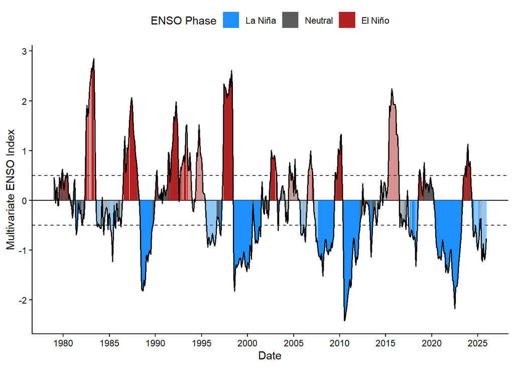

```r
ggplot(data = filter(MEI_long, !is.na(MEI)), aes(x = Date, y = MEI)) +
  theme_classic() +
  geom_hline(yintercept = 0, linetype = "solid") +
  geom_hline(yintercept = 0.5, linetype = "dashed") +
  geom_hline(yintercept = -0.5, linetype = "dashed") +
  geom_col(aes(x = Date, y = MEI, fill = ENSOphase)) +
  geom_line(linewidth = 0.7) +
  scale_x_date(breaks = seq(as.Date("1980-01-01"), as.Date("2025-01-01"),
                            by = "5 years"),
               date_labels = "%Y") +
  scale_y_continuous(name = "Multivariate ENSO Index") +
  scale_fill_manual(name = "ENSO Phase",
                    values = c("dodgerblue","gray36","firebrick"),
                    labels = c("La Ni\u00F1a","Neutral","El Ni\u00F1o")) +
  theme(legend.position = "top",
        axis.text = element_text(color = "black"))
```

To save this figure, use the `ggsave` function and specify the size and units.

```r
MEIseriesfinal <-
  ggplot(data = filter(MEI_long, !is.na(MEI)), aes(x = Date, y = MEI)) +
  theme_classic() +
  geom_hline(yintercept = 0, linetype = "solid") +
  geom_hline(yintercept = 0.5, linetype = "dashed") +
  geom_hline(yintercept = -0.5, linetype = "dashed") +
  geom_col(aes(x = Date, y = MEI, fill = ENSOphase)) +
  geom_line(linewidth = 0.7) +
  scale_x_date(breaks = seq(as.Date("1980-01-01"), as.Date("2025-01-01"),
                            by = "5 years"),
               date_labels = "%Y") +
  scale_y_continuous(name = "Multivariate ENSO Index") +
  scale_fill_manual(name = "ENSO Phase",
                    values = c("dodgerblue","gray36","firebrick"),
                    labels = c("La Ni\u00F1a","Neutral","El Ni\u00F1o")) +
  theme(legend.position = "top",
        axis.text = element_text(color = "black"))

ggsave(MEIseriesfinal, filename = "MEI Time Series.png",
       dpi = 2000, height = 4, width = 6, units = "in")
```